# Platform Observer API

8.1.0  
Platform Observer API

# Platform Observer API

X-CUBE-AI Expansion Package

r1.1

AI PLATFORM r8.1.0 (Embedded Inference Client API 1.2.0)

Command Line Interface r1.7.0

# Purpose

For advanced run-time, debug or profiling purposes, an AI client application can register a call-back function to be notified before or/end after the execution of a c-node. As detailed in the “C-graph description” [CLI] section, each node is identified by its executing index: `'c_id'`. The call-back can be used to measure the execution time or/and to dump the intermediate values.

**Note** — During the execution of the `ai_<network>_run()` function, the registered callback is executed synchronously in the context of the caller.

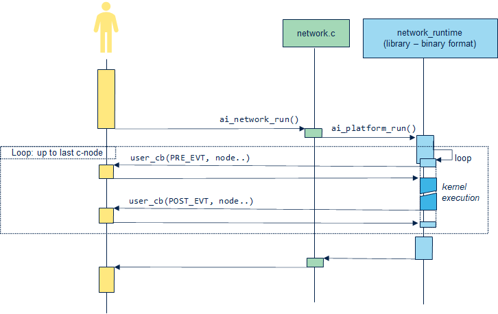

# Use cases

## User call-back registration for profiling

Minimal code snippet is updated to register a basic call-back function that logs the number of used core cycles after each executing of a node (More advanced implementation can be found in `'aiSystemPerformance.c'` file).

```cpp
#include "ai_platform_interface.h"
...
/*
 * Observer initialization
 */

/* Minimal ctx to store the timestamp (before execution) */
struct u_observer_ctx {
  uint64_t ts;
  uint32_t n_events;
};

struct u_observer_ctx u_observer_ctx;

static ai_u32 u_observer_cb(const ai_handle cookie,
    const ai_u32 flags,
    const ai_observer_node *node) {

  uint64_t ts = dwtGetCycles();  /* time stamp entry */
  struct u_observer_ctx *ctx = (u_observer_ctx *)cookie;

  if (flags & AI_OBSERVER_POST_EVT) {
    printf("%d - cpu cycles: %lld\r\n", node->c_idx, ts - ctx->ts);
    ctx->n_events++;
  }
  ctx->ts = dwtGetCycles(); /* time stamp exit */
  return 0;
}

/* Register a call-back to be notified before
   and after each executing of a c-node */
int aiObserverSetup() {

  if (!ai_platform_observer_register(network,
     u_observer_cb, &u_observer_ctx,
     AI_OBSERVER_PRE_EVT | AI_OBSERVER_POST_EVT)) {
    err = ai_network_get_error(network);
    printf("E: AI ai_platform_observer_register error - type=%d code=%d\r\n", err.type, err.code);
    return -1;
  }
  return 0;
}
```

## Node-per-node inspection

The `ai_platform_observer_node_info()` function can be used to pass through the executing C-graph structure retrieving the tensor attributes node-per-node. A set of helper macros (`AI_TENSOR_XXX` from `ai_platform_interface.h` file) should be used to retrieve or to manipulate the returned tensor object: `t`.

```cpp
#include "ai_platform_interface.h"
#include "core_common.h"
#include "core_private.h"

{
  ai_observer_node node_info;
  ai_tensor_list *tl;

  node_info.c_idx = 0; /* starting with the first node */
  while (ai_platform_observer_node_info(network, &node_info)) {
    /* Check if the node is a "Time Distributed" operator. In this
     * case, weight/bias tensors are provided through the inner object
     * - node_info.inner_tensors != NULL condition can be also used
     */
    const ai_bool is_time_dist = (node_info.type & 0x8000 != 0);
    node_info.type &= 0x7FFF;
    /* Retrieve the list of the input tensors */
    tl = GET_TENSOR_LIST_IN(node_info.tensors);
    if (tl) {
      AI_FOR_EACH_TENSOR_LIST_DO(i, t, tl) {
        ...
      }
    }
    /* Retrieve the list of the output tensors */
    tl = GET_TENSOR_LIST_OUT(node_info.tensors);
    if (tl) {
      AI_FOR_EACH_TENSOR_LIST_DO(i, t, tl) {
        ...
      }
    }
    /* Retrieve the list of the weight/bias tensors */
    if (is_time_dist)
      tl = GET_TENSOR_LIST_WEIGTHS(node_info.inner_tensors);
    else
      tl = GET_TENSOR_LIST_WEIGTHS(node_info.tensors);
    if (tl) {
      AI_FOR_EACH_TENSOR_LIST_DO(i, t, tl) {
        ...
      }
    }
    /* Retrieve the list of the scratch tensors */
    if (is_time_dist)
      tl = GET_TENSOR_LIST_SCRATCH(node_info.inner_tensors);
    else
      tl = GET_TENSOR_LIST_SCRATCH(node_info.tensors);
    if (tl) {
      AI_FOR_EACH_TENSOR_LIST_DO(i, t, tl) {
        ...
      }
    }
    node_info.c_idx++;
  } /* end of the while loop */
  ...
}
```

| macro | description |
| --- | --- |
| `AI_TENSOR_ARRAY_BYTE_SIZE(t)` | returns the size in byte of the data buffer. |
| `AI_TENSOR_ARRAY_GET_DATA_ADDR(t)` | returns the effective address of the data buffer. |
| `AI_TENSOR_ARRAY_UPDATE_DATA_ADDR(t, addr)` | set a new effective address. It should be 4-bytes aligned. Previous address is forgotten and not saved (see next section). |

**Warning** — `ai_platform_observer_node_info()` should be called with an initialized instance to be sure to have a complete and ready-to-use initialization of the internal runtime data structure (in particular the arrays objects which handle the data of the tensors).

## Copy-before-run use-case

Kernels from the network runtime library are designed to take account flexible data placement, thanks to the usage of the scratch buffers or stack-based technics. After profiling session, and if a static placement approach (based on the `'--split-weights'` option) is not sufficient or adapted, it is also possible to improve the inference time, by *copy-before-run* the critical weights/bias data buffer in a low latency memory.

Following code snippet illustrates the usage of a software “cache” memory to store the weights/bias of a specific critical layer before to call the `ai_<name>_run()` function. Particular compiler directive (tool-chain dependent) can be used to place `_w_cache` object.

```cpp
#include <string.h>
#include "ai_platform_interface.h"

#define ALIGN_UP(num, align) \
    (((num) + ((align) - 1)) & ~((align) - 1))

AI_ALIGN(4)
static ai_u8 _w_cache[XXX]; /* reserve buffer to cache the weights */

int aiCacheWeights(void) {
  ai_observer_node node_info;
  node_info.c_idx = ID; /* index of the critical node */
  if (ai_platform_observer_node_info(network, &node_info)) {
    ai_tensor_list *tl;
    tl = GET_TENSOR_LIST_WEIGTHS(node_info.tensors);
    uintptr_t dst_addr = (uintptr_t)&_w_cache[0];
    AI_FOR_EACH_TENSOR_LIST_DO(i, t, tl) {
        /* Retrieve the @/size of the data */
        const uintptr_t src_addr = (uintptr_t)AI_TENSOR_ARRAY_GET_DATA_ADDR(t);
        const ai_size sz = AI_TENSOR_ARRAY_BYTE_SIZE(t);
        /* Copy the dta tensor in the SW cache */
        memcpy(dst_addr, src_addr, sz);
        /* set the new effective address */
        AI_TENSOR_ARRAY_UPDATE_DATA_ADDR(t, dst_addr);
        dst_addr += ALIGN_UP(sz, 4);
      }
  }
  return 0;
}
```

## Dumping intermediate output

Following code snippet illustrates a simple call-back to dump an output of a given internal layer `C_ID`. Internal tensor description is converted to a `ai_buffer`’-type data.

```cpp
#include "ai_platform_interface.h"
...

#define C_ID (12)  /* c-id of the operator which must be dumped */

static ai_u32 u_observer_cb(const ai_handle cookie,
    const ai_u32 flags,
    const ai_observer_node *node) {

    ai_tensor_list *tl;

    if (node->c_idx == C_ID) {
      tl = GET_TENSOR_LIST_OUT(node_info.tensors);
      AI_FOR_EACH_TENSOR_LIST_DO(i, t, tl) {
          ai_float scale = AI_TENSOR_INTEGER_GET_SCALE(t, 0);
          ai_i32 zero_point = 0;

          if (AI_TENSOR_FMT_GET_SIGN(t))
            zero_point = AI_TENSOR_INTEGER_GET_ZEROPOINT_I8(t, 0);
          else
            zero_point = AI_TENSOR_INTEGER_GET_ZEROPOINT_U8(t, 0);

          const ai_buffer_format fmt = AI_TENSOR_GET_FMT(t);
          const ai_i32 shape_size_ = AI_SHAPE_SIZE(AI_TENSOR_SHAPE(t));
          const ai_i32 b_ = AI_SHAPE_IN_CH(AI_TENSOR_SHAPE(t));
          const ai_i32 h_ = AI_SHAPE_H(AI_TENSOR_SHAPE(t));
          const ai_i32 w_ = AI_SHAPE_W(AI_TENSOR_SHAPE(t));
          const ai_i32 ch_ = AI_SHAPE_CH(AI_TENSOR_SHAPE(t));
          /* new dimension if available : shape_size_ >= 5 else 1 is returned */
          const ai_i32 d_ = AI_SHAPE_D(AI_TENSOR_SHAPE(t));
          const ai_i32 e_ = AI_SHAPE_E(AI_TENSOR_SHAPE(t));

          const ai_size size = AI_TENSOR_ARRAY_BYTE_SIZE(t);
          const ai_handle data = AI_TENSOR_ARRAY_GET_DATA_ADDR(t);
          ...
          /** @brief User code to dump the data */
          ...
        }
      }
    }

  return 0;
}

...
/* registered call-back is only raised for the POST event */
ai_platform_observer_register(network,
     u_observer_cb, &u_observer_ctx, AI_OBSERVER_POST_EVT))
...
```

## End-of-process input buffer notification

Following code snippet illustrates a simple call-back to notify the user application when an input buffer is processed by the `C_ID` layer. This can be use-full to anticipate a HW capture process (DMA-based) before the end of the inference.

**Warning** — The input buffer should be not allocated in the *activations* buffer else there is no guarantee that the memory region will be not used by the other operators before the end of the inference.

```cpp
#include "ai_platform_interface.h"
...

#define C_ID (0)  /* c-id of the operator which processes the input buffer */

static ai_u32 u_observer_cb(const ai_handle cookie,
    const ai_u32 flags,
    const ai_observer_node *node) {

    if (node->c_idx == C_ID) {
      /* start a new capture process to fill the input buffer before the end-of
         inference */
        ...
    }

  return 0;
}

...
/* registered call-back is only raised for the POST event */
ai_platform_observer_register(network,
     u_observer_cb, &u_observer_ctx, AI_OBSERVER_POST_EVT))
...
```

# Platform Observer API

## ai_observer_node

The `ai_platform_observer_node_info()` function and registered call-back function use the following `ai_observer_node` data structure to report the tensor attributes for a given node: `c_idx`.

```cpp
/* @file ai_platform_interface.h */

typedef struct ai_observer_node_s {
  ai_u16            c_idx;   /*!< node index (position in the execution list) */
  ai_u16            type;    /*!< node type info */
  ai_u16            id;      /*!< node id assigned by code generator to reference the model layer */
  ai_u16            unused;  /*!< unused field for alignment */
  const ai_tensor_chain* inner_tensors; /*!< pointer to the inner tensors if available */
  const ai_tensor_chain* tensors;       /*!< pointer to a 4 sized array */
} ai_observer_node;
```

| field | description |
| --- | --- |
| c_idx | index of the associated c-node (also called c-id) |
| type | define the type of the c-operator (see `layers_list.h` file: `100XX` values). |
| id | index of the original operator from the imported model. |
| tensors | entry point to retrieve the list of [I], [O], [W] and [S] tensors. |
| inner_tensors | if the operator is a “Time Distributed” operator, [W] and [S] tensors are returned through this entry, else this field is NULL. |

If `type & 0x8000 != 0`, the associated operator is a “Time Distributed” operator and `tensors` and `inner_tensors` fields should be used to retrieve all of the tensors: [I], [O], [W] and [S] lists (see “Node-by-node inspection” section).

**Warning** — `inner_tensors` field is always NULL and the most significant bit of `type` is not updated when the call-back is called.

## ai_platform_observer_node_info()

```cpp
ai_bool ai_platform_observer_node_info(
    ai_handle network, ai_observer_node *node_info);
```

This function populates the referenced `ai_observer_node` structure to retrieve the node and associated tensor attributes. Requested node index is defined through the `node_info.c_idx` field. If the `network` parameter is not a valid network instance or the index is out-of-range, `ai_false` is returned.

## ai_platform_observer_register()

```cpp
ai_bool ai_platform_observer_register(
    ai_handle network,
    ai_observer_node_cb cb,
    ai_handle cookie,
    ai_u32 flags););
```

This function registers an user call-back function. Only one call-back can be registered a time for a given network instance.

- `cb` pointer of an user callback function (see “User call-back registration” code snippet)
- `cookie` reference of an user context/object which is returned without modification.
- `flags` bit-wise mask to indicate the type of requested events.

| flags | event type |
| --- | --- |
| `AI_OBSERVER_INIT_EVT` | initialization (at the end of the call of `ai_<name>_init()`) |
| `AI_OBSERVER_PRE_EVT` | before the execution of the kernel (during the call of `ai_<name>_run()`) |
| `AI_OBSERVER_POST_EVT` | after the execution of the kernel (during the call of `ai_<name>_run()`) |

```cpp
typedef ai_u32 (*ai_observer_node_cb)(const ai_handle cookie,
    const ai_u32 flags,
    const ai_observer_node *node)
```

When the call-back is called, the previous `'flags'` event types are extended with the following values:

| flags | event type |
| --- | --- |
| `AI_OBSERVER_FIRST_EVT` | event related to the first node. |
| `AI_OBSERVER_LAST_EVT` | event related to the last node. |

## ai_platform_observer_unregister()

```cpp
ai_bool ai_platform_observer_unregister(ai_handle network,
    ai_observer_node_cb cb, ai_handle cookie);
```

This function un-registers the registered user call-back function. The `'cb'` pointer used to register it should be used.

# References

| ref | description |
| --- | --- |
| [DS] | X-CUBE-AI - AI expansion pack for STM32CubeMX https://www.st.com/en/embedded-software/x-cube-ai.html |
| [UM] | User manual - Getting started with X-CUBE-AI Expansion Package for Artificial Intelligence (AI) [(pdf)](https://www.st.com/resource/en/user_manual/dm00570145.pdf) |
| [CLI] | stm32ai - Command Line Interface (link) |
| [API] | Embedded inference client API (link) |
| [METRIC] | Evaluation report and metrics (link) |
| [TFL] | TensorFlow Lite toolbox (link) |
| [KERAS] | Keras toolbox (link) |
| [ONNX] | ONNX toolbox (link) |
| [ONNX-ML] | Machine Learning support (ONNX-ML operators) (link) |
| [DQNN] | Deep Quantized Neural Network support (link) |
| [FAQS] | FAQ generic, validation, quantization |
| [QUANT] | Quantization (link) |
| [QUANT_CMD] | Quantization Command (link) |
| [RELOC] | Relocatable binary network support (link) |
| [CUST] | Support of the Keras Lambda/custom layers (link) |
| [TFLM] | TensorFlow Lite for Microcontroller support (link) |
| [INST] | Setting the environment (link) |
| [OBS] | Platform Observer API (link) |
| [C-RUN] | Executing locally a generated c-model (link) |
| [BREAK] | API Breaking changes (link) |
| [CRC] | STM32 CRC IP as shared resource (link) |